# Description

## Model 4

- Optimizer: Adam
- Epoch: 50
- Layers: 8 (5 Layers + 3 Droupouts)
- Techique: Dropout
- Learning Rate: 0.0001

```python
backend.clear_session()
#Fixing the seed for random number generators so that we can ensure we receive the same output everytime
np.random.seed(1)
import random
random.seed(1)
tf.random.set_seed(1)
```

```python
model3 = Sequential()
model3.add(Dense(256,activation='relu',input_dim = X_train.shape[1]))
model3.add(Dropout(0.3))
model3.add(Dense(128,activation='relu'))
model3.add(Dropout(0.3))
model3.add(Dense(64,activation='relu'))
model3.add(Dropout(0.3))
model3.add(Dense(32,activation='relu'))
model3.add(Dense(1, activation = 'sigmoid'))
```

```python
# Create optimizer with default learning rate
#Compiling the ANN with Adam optimizer and binary cross entropy loss function
optimizer = tf.keras.optimizers.Adam(0.0001)
#optimizer = 'SGD'
model3.compile(optimizer = optimizer, loss = 'binary_crossentropy', metrics = [tf.keras.metrics.Recall()])
```

```python
model3.summary()
```

```
Model: "sequential"
_________________________________________________________________
 Layer (type)                Output Shape              Param #
=================================================================
 dense (Dense)               (None, 256)               3072

 dropout (Dropout)           (None, 256)               0

 dense_1 (Dense)             (None, 128)               32896

 dropout_1 (Dropout)         (None, 128)               0

 dense_2 (Dense)             (None, 64)                8256

 dropout_2 (Dropout)         (None, 64)                0

 dense_3 (Dense)             (None, 32)                2080

 dense_4 (Dense)             (None, 1)                 33

=================================================================
Total params: 46,337
Trainable params: 46,337
Non-trainable params: 0
_________________________________________________________________
```

```python
history=model3.fit(X_train, y_train,
          validation_split=0.2,
          epochs=50,
          batch_size=32,verbose=1)
```

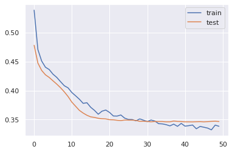

```python
# Capturing learning history per epoch
hist  = pd.DataFrame(history.history)
hist['epoch'] = history.epoch

# Plotting accuracy at different epochs
plt.plot(hist['loss'])
plt.plot(hist['val_loss'])
plt.legend(("train", "test") , loc =0)

#Printing results
results = model3.evaluate(X_test, y_test)
```

- Here the model seems to be well fitted, as the distance between the train curve and test curve is converging.

```
Best Threshold=0.217661, G-Mean=0.765
```

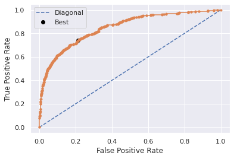

```python
from sklearn.metrics import roc_curve

from matplotlib import pyplot


# predict probabilities
yhat1 = model3.predict(X_test)
# keep probabilities for the positive outcome only
yhat1 = yhat1[:, 0]
# calculate roc curves
fpr, tpr, thresholds1 = roc_curve(y_test, yhat1)
# calculate the g-mean for each threshold
gmeans1 = np.sqrt(tpr * (1-fpr))
# locate the index of the largest g-mean
ix = np.argmax(gmeans1)
print('Best Threshold=%f, G-Mean=%.3f' % (thresholds1[ix], gmeans1[ix]))
# plot the roc curve for the model
pyplot.plot([0,1], [0,1], linestyle='--', label='Diagonal')
pyplot.plot(fpr, tpr, marker='.')
pyplot.scatter(fpr[ix], tpr[ix], marker='o', color='black', label='Best')
# axis labels
pyplot.xlabel('False Positive Rate')
pyplot.ylabel('True Positive Rate')
pyplot.legend()
# show the plot
pyplot.show()
```

```python
# Calculating different metrics on train set
ANN_train_4 = model_performance_classification_sklearn(model3, X_train, y_train)
print("Training performance:")
ANN_train_4
```

```
Training performance:
```

|  | Accuracy | Recall | Precision | F1 |
| --- | --- | --- | --- | --- |
| 0 | 0.776 | 0.816 | 0.471 | 0.597 |

```python
# Calculating different metrics on test set
ANN_test_4 = model_performance_classification_sklearn(model3, X_test, y_test)
print("Testing performance:")
ANN_test_4
```

```
Testing performance:
```

|  | Accuracy | Recall | Precision | F1 |
| --- | --- | --- | --- | --- |
| 0 | 0.755 | 0.769 | 0.442 | 0.561 |

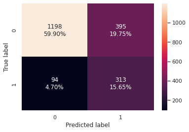

```python
# creating confusion matrix
confusion_matrix_sklearn(model3, X_test, y_test)
```

- Model has a superior performance to all previous models and generalized well on unseen data.
- There is an improvement from the previous model and the model is generalizing well on unseen data

## Model 5

- Optimizer: Adam
- Epoch: 50
- Layers: 8 (5 Layers + 3 Dropouts)
- Techique: Dropout and Oversampling
- Learning Rate: 0.0001

```python
print("Before Oversampling, counts of label 'Yes': {}".format(sum(y_train.Exited  == 1)))
print("Before Oversampling, counts of label 'No': {} \n".format(sum(y_train.Exited  == 0)))

sm = SMOTE(
    sampling_strategy=1, k_neighbors=5, random_state=1
)  # Synthetic Minority Over Sampling Technique
X_train_over, y_train_over = sm.fit_resample(X_train, y_train)


print("After Oversampling, counts of label 'Yes': {}".format(sum(y_train_over.Exited == 1)))
print("After Oversampling, counts of label 'No': {} \n".format(sum(y_train_over.Exited == 0)))


print("After Oversampling, the shape of train_X: {}".format(X_train_over.shape))
print("After Oversampling, the shape of train_y: {} \n".format(y_train_over.shape))
```

```
Before Oversampling, counts of label 'Yes': 1630
Before Oversampling, counts of label 'No': 6370

After Oversampling, counts of label 'Yes': 6370
After Oversampling, counts of label 'No': 6370

After Oversampling, the shape of train_X: (12740, 11)
After Oversampling, the shape of train_y: (12740, 1)
```

```python
backend.clear_session()
#Fixing the seed for random number generators so that we can ensure we receive the same output everytime
np.random.seed(1)
import random
random.seed(1)
tf.random.set_seed(1)
```

```python
model4 = Sequential()
model4.add(Dense(256,activation='relu',input_dim = X_train.shape[1]))
model4.add(Dropout(0.3))
model4.add(Dense(128,activation='relu'))
model4.add(Dropout(0.3))
model4.add(Dense(64,activation='relu'))
model4.add(Dropout(0.3))
model4.add(Dense(32,activation='relu'))
model4.add(Dense(1, activation = 'sigmoid'))
```

```python
# Create optimizer with default learning rate
#Compiling the ANN with Adam optimizer and binary cross entropy loss function
optimizer = tf.keras.optimizers.Adam(0.0001)
#optimizer = 'SGD'
model4.compile(optimizer = optimizer, loss = 'binary_crossentropy', metrics = [tf.keras.metrics.Recall()])
```

```python
model4.summary()
```

```
Model: "sequential"
_________________________________________________________________
 Layer (type)                Output Shape              Param #
=================================================================
 dense (Dense)               (None, 256)               3072

 dropout (Dropout)           (None, 256)               0

 dense_1 (Dense)             (None, 128)               32896

 dropout_1 (Dropout)         (None, 128)               0

 dense_2 (Dense)             (None, 64)                8256

 dropout_2 (Dropout)         (None, 64)                0

 dense_3 (Dense)             (None, 32)                2080

 dense_4 (Dense)             (None, 1)                 33

=================================================================
Total params: 46,337
Trainable params: 46,337
Non-trainable params: 0
_________________________________________________________________
```

```python
history=model4.fit(X_train_over, y_train_over,
          validation_split=0.2,
          epochs=50,
          batch_size=32,verbose=1)
```

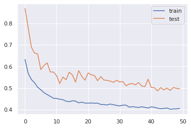

```python
# Capturing learning history per epoch
hist  = pd.DataFrame(history.history)
hist['epoch'] = history.epoch

# Plotting accuracy at different epochs
plt.plot(hist['loss'])
plt.plot(hist['val_loss'])
plt.legend(("train", "test") , loc =0)

#Printing results
results = model4.evaluate(X_test, y_test)
```

- Here the model seems to be well fitted, as the distance between the train curve and test curve is converging

```
Best Threshold=0.305178, G-Mean=0.762
```

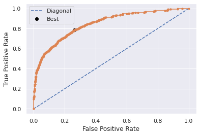

```python
from sklearn.metrics import roc_curve

from matplotlib import pyplot


# predict probabilities
yhat1 = model4.predict(X_test)
# keep probabilities for the positive outcome only
yhat1 = yhat1[:, 0]
# calculate roc curves
fpr, tpr, thresholds1 = roc_curve(y_test, yhat1)
# calculate the g-mean for each threshold
gmeans1 = np.sqrt(tpr * (1-fpr))
# locate the index of the largest g-mean
ix = np.argmax(gmeans1)
print('Best Threshold=%f, G-Mean=%.3f' % (thresholds1[ix], gmeans1[ix]))
# plot the roc curve for the model
pyplot.plot([0,1], [0,1], linestyle='--', label='Diagonal')
pyplot.plot(fpr, tpr, marker='.')
pyplot.scatter(fpr[ix], tpr[ix], marker='o', color='black', label='Best')
# axis labels
pyplot.xlabel('False Positive Rate')
pyplot.ylabel('True Positive Rate')
pyplot.legend()
# show the plot
pyplot.show()
```

```python
# Calculating different metrics on train set
ANN_train_5 = model_performance_classification_sklearn(model4, X_train_over, y_train_over)
print("Training performance:")
ANN_train_5
```

```
Training performance:
```

|  | Accuracy | Recall | Precision | F1 |
| --- | --- | --- | --- | --- |
| 0 | 0.774 | 0.951 | 0.703 | 0.808 |

```python
# Calculating different metrics on test set
ANN_test_5 = model_performance_classification_sklearn(model4, X_test, y_test)
print("Testing performance:")
ANN_test_5
```

```
Testing performance:
```

|  | Accuracy | Recall | Precision | F1 |
| --- | --- | --- | --- | --- |
| 0 | 0.642 | 0.885 | 0.350 | 0.502 |

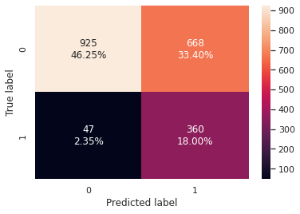

```python
# creating confusion matrix
confusion_matrix_sklearn(model4, X_test, y_test)
```

- The oversampled improvement of Model 4 gave has given the best performance so far
- There is an improvement from the previous model and the model is generalizing well on unseen data

## Model 6

- Optimizer: Adam
- Epoch: 50
- Oversampling
- Keras Tuner

```python
backend.clear_session()
#Fixing the seed for random number generators so that we can ensure we receive the same output everytime
np.random.seed(1)
import random
random.seed(1)
tf.random.set_seed(1)
```

```python
def build_model(h):
    model = keras.Sequential()
    for i in range(h.Int('num_layers', 2, 10)):
        model.add(layers.Dense(units=h.Int('units_' + str(i),
                                            min_value=32,
                                            max_value=256,
                                            step=32),
                               activation='relu'))
    model.add(layers.Dense(1, activation='sigmoid'))
    model.compile(
        optimizer=keras.optimizers.Adam(
            h.Choice('learning_rate', [1e-2, 1e-3, 1e-4])),
        loss='binary_crossentropy',
        metrics=[tf.keras.metrics.Recall()])
    return model
```

```python
tuner = RandomSearch(
    build_model,
    objective='val_loss',
    max_trials=5,
    executions_per_trial=3,
    project_name='Job_Switch')
```

```
INFO:tensorflow:Reloading Oracle from existing project ./Job_Switch/oracle.json
INFO:tensorflow:Reloading Tuner from ./Job_Switch/tuner0.json
```

```python
tuner.search_space_summary()
```

```
Search space summary
Default search space size: 11
num_layers (Int)
{'default': None, 'conditions': [], 'min_value': 2, 'max_value': 10, 'step': 1, 'sampling': None}
units_0 (Int)
{'default': None, 'conditions': [], 'min_value': 32, 'max_value': 256, 'step': 32, 'sampling': None}
units_1 (Int)
{'default': None, 'conditions': [], 'min_value': 32, 'max_value': 256, 'step': 32, 'sampling': None}
learning_rate (Choice)
{'default': 0.01, 'conditions': [], 'values': [0.01, 0.001, 0.0001], 'ordered': True}
units_2 (Int)
{'default': None, 'conditions': [], 'min_value': 32, 'max_value': 256, 'step': 32, 'sampling': None}
units_3 (Int)
{'default': None, 'conditions': [], 'min_value': 32, 'max_value': 256, 'step': 32, 'sampling': None}
units_4 (Int)
{'default': None, 'conditions': [], 'min_value': 32, 'max_value': 256, 'step': 32, 'sampling': None}
units_5 (Int)
{'default': None, 'conditions': [], 'min_value': 32, 'max_value': 256, 'step': 32, 'sampling': None}
units_6 (Int)
{'default': None, 'conditions': [], 'min_value': 32, 'max_value': 256, 'step': 32, 'sampling': None}
units_7 (Int)
{'default': None, 'conditions': [], 'min_value': 32, 'max_value': 256, 'step': 32, 'sampling': None}
units_8 (Int)
{'default': None, 'conditions': [], 'min_value': 32, 'max_value': 256, 'step': 32, 'sampling': None}
```

```python
tuner.search(X_train_over, y_train_over,
             epochs=5,
             validation_split = 0.2)
```

```
INFO:tensorflow:Oracle triggered exit
```

```python
tuner.results_summary()
```

```
Results summary
Results in ./Job_Switch
Showing 10 best trials
<keras_tuner.engine.objective.Objective object at 0x7fe0f7b21c10>
Trial summary
Hyperparameters:
num_layers: 8
units_0: 160
units_1: 224
learning_rate: 0.001
units_2: 160
units_3: 32
units_4: 192
units_5: 96
units_6: 192
units_7: 160
units_8: 160
Score: 0.4878866871198018
Trial summary
Hyperparameters:
num_layers: 8
units_0: 160
units_1: 160
learning_rate: 0.001
units_2: 224
units_3: 96
units_4: 160
units_5: 64
units_6: 64
units_7: 192
units_8: 160
Score: 0.49392348527908325
Trial summary
Hyperparameters:
num_layers: 8
units_0: 64
units_1: 192
learning_rate: 0.0001
units_2: 64
units_3: 64
```

[output cut: 12 more lines]

```
units_2: 32
units_3: 32
units_4: 32
units_5: 32
units_6: 32
units_7: 32
units_8: 32
Score: 0.5732166568438212
Trial summary
Hyperparameters:
num_layers: 2
units_0: 160
units_1: 256
learning_rate: 0.0001
Score: 0.6055531700452169
```

```python
backend.clear_session()
#Fixing the seed for random number generators so that we can ensure we receive the same output everytime
np.random.seed(1)
import random
random.seed(1)
tf.random.set_seed(1)
```

```python
model5 = Sequential()
model5.add(Dense(192,activation='relu',kernel_initializer='he_uniform',input_dim = X_train.shape[1]))
model5.add(Dense(64,activation='relu',kernel_initializer='he_uniform'))
model5.add(Dense(32,activation='relu',kernel_initializer='he_uniform'))
model5.add(Dense(32,activation='relu',kernel_initializer='he_uniform'))
model5.add(Dense(32,activation='relu',kernel_initializer='he_uniform'))
model5.add(Dense(32,activation='relu',kernel_initializer='he_uniform'))
model5.add(Dense(32,activation='relu',kernel_initializer='he_uniform'))
model5.add(Dense(32,activation='relu',kernel_initializer='he_uniform'))
model5.add(Dense(32,activation='relu',kernel_initializer='he_uniform'))
model5.add(Dense(1, activation = 'sigmoid'))
```

```python
# Create optimizer with default learning rate
#Compiling the ANN with Adam optimizer and binary cross entropy loss function
optimizer = tf.keras.optimizers.Adam(0.01)
#optimizer = 'SGD'
model5.compile(optimizer = optimizer, loss = 'binary_crossentropy', metrics = [tf.keras.metrics.Recall()])
```

```python
model5.summary()
```

```
Model: "sequential"
_________________________________________________________________
 Layer (type)                Output Shape              Param #
=================================================================
 dense (Dense)               (None, 192)               2304

 dense_1 (Dense)             (None, 64)                12352

 dense_2 (Dense)             (None, 32)                2080

 dense_3 (Dense)             (None, 32)                1056

 dense_4 (Dense)             (None, 32)                1056

 dense_5 (Dense)             (None, 32)                1056

 dense_6 (Dense)             (None, 32)                1056

 dense_7 (Dense)             (None, 32)                1056

 dense_8 (Dense)             (None, 32)                1056

 dense_9 (Dense)             (None, 1)                 33

=================================================================
Total params: 23,105
Trainable params: 23,105
Non-trainable params: 0
_________________________________________________________________
```

```python
history=model5.fit(X_train_over, y_train_over,
          validation_split=0.2,
          epochs=50,
          batch_size=32,verbose=1)
```

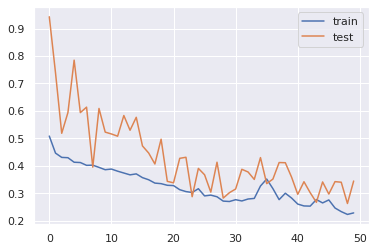

```python
# Capturing learning history per epoch
hist  = pd.DataFrame(history.history)
hist['epoch'] = history.epoch

# Plotting accuracy at different epochs
plt.plot(hist['loss'])
plt.plot(hist['val_loss'])
plt.legend(("train", "test") , loc =0)

#Printing results
results = model4.evaluate(X_test, y_test)
```

- Here the model does not give a smooth curve but seems to be conveerging

```
Best Threshold=0.108149, G-Mean=0.729
```

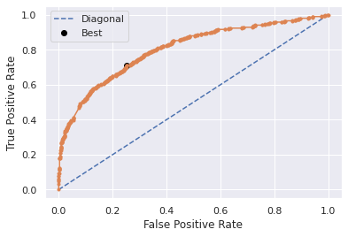

```python
from sklearn.metrics import roc_curve

from matplotlib import pyplot


# predict probabilities
yhat1 = model5.predict(X_test)
# keep probabilities for the positive outcome only
yhat1 = yhat1[:, 0]
# calculate roc curves
fpr, tpr, thresholds1 = roc_curve(y_test, yhat1)
# calculate the g-mean for each threshold
gmeans1 = np.sqrt(tpr * (1-fpr))
# locate the index of the largest g-mean
ix = np.argmax(gmeans1)
print('Best Threshold=%f, G-Mean=%.3f' % (thresholds1[ix], gmeans1[ix]))
# plot the roc curve for the model
pyplot.plot([0,1], [0,1], linestyle='--', label='Diagonal')
pyplot.plot(fpr, tpr, marker='.')
pyplot.scatter(fpr[ix], tpr[ix], marker='o', color='black', label='Best')
# axis labels
pyplot.xlabel('False Positive Rate')
pyplot.ylabel('True Positive Rate')
pyplot.legend()
# show the plot
pyplot.show()
```

```python
# Calculating different metrics on train set
ANN_train_6 = model_performance_classification_sklearn(model5, X_train_over, y_train_over)
print("Training performance:")
ANN_train_6
```

```
Training performance:
```

|  | Accuracy | Recall | Precision | F1 |
| --- | --- | --- | --- | --- |
| 0 | 0.922 | 0.964 | 0.890 | 0.926 |

```python
# Calculating different metrics on test set
ANN_test_6 = model_performance_classification_sklearn(model5, X_test, y_test)
print("Testing performance:")
ANN_test_6
```

```
Testing performance:
```

|  | Accuracy | Recall | Precision | F1 |
| --- | --- | --- | --- | --- |
| 0 | 0.764 | 0.651 | 0.445 | 0.529 |

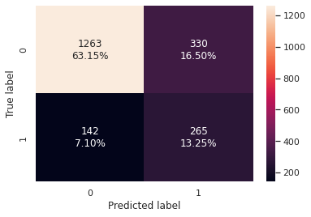

```python
# creating confusion matrix
confusion_matrix_sklearn(model5, X_test, y_test)
```

- The tuned model gave a worse performance on the test set as it is overfitting
- There is a worse performance from the previous model and the model is overfitted

## Model 7

- Model 6 with Grid search improvements and Dropout Layers

```python
backend.clear_session()
np.random.seed(1)
import random
random.seed(1)
tf.random.set_seed(1)
```

```python
def create_model_v6(lr,batch_size):
    np.random.seed(1)
    model6 = Sequential()
    model6.add(Dense(192,activation='relu',input_dim = X_train.shape[1]))
    model6.add(Dropout(0.3))
    model6.add(Dense(64,activation='relu'))
    model6.add(Dropout(0.3))
    model6.add(Dense(32,activation='relu'))
    model6.add(Dropout(0.3))
    model6.add(Dense(32,activation='relu'))
    model6.add(Dropout(0.3))
    model6.add(Dense(32,activation='relu'))
    model6.add(Dropout(0.3))
    model6.add(Dense(32,activation='relu'))
    model6.add(Dropout(0.3))
    model6.add(Dense(32,activation='relu'))
    model6.add(Dropout(0.3))
    model6.add(Dense(32,activation='relu'))
    model6.add(Dropout(0.3))
    model6.add(Dense(32,activation='relu'))
    model6.add(Dense(1, activation='sigmoid'))

    #compile model
    optimizer = tf.keras.optimizers.Adam(learning_rate=lr)
    model6.compile(optimizer = optimizer,loss = 'binary_crossentropy', metrics = [tf.keras.metrics.Recall()])
    return model
```

```python
keras_estimator = KerasClassifier(build_fn=create_model_v6, verbose=1)
```

```python
# define the grid search parameters
param_grid = {
    'batch_size':[32, 64, 128],
    "lr":[0.0001,0.001,0.01,0.1],}

kfold_splits = 3
grid = GridSearchCV(estimator=keras_estimator,
                    verbose=1,
                    cv=kfold_splits,
                    param_grid=param_grid,n_jobs=-1)
grid_result = grid.fit(X_train_over, y_train_over,validation_split=0.2,verbose=1)
```

[output not shown]

```python
# Summarize results
print("Best: %f using %s" % (grid_result.best_score_, grid_result.best_params_))
means = grid_result.cv_results_['mean_test_score']
stds = grid_result.cv_results_['std_test_score']
params = grid_result.cv_results_['params']
```

```
Best: nan using {'batch_size': 32, 'lr': 0.0001}
```

```python
estimator_v6=create_model_v6(batch_size=grid_result.best_params_['batch_size'],lr=grid_result.best_params_['lr'])

estimator_v6.summary()
```

[output not shown]

```python
optimizer = tf.keras.optimizers.Adam(grid_result.best_params_['lr'])
estimator_v6.compile(loss='binary_crossentropy',
                     optimizer=optimizer, metrics=[tf.keras.metrics.Recall()])
history=estimator_v6.fit(X_train_over, y_train_over,
                         epochs=50, batch_size = grid_result.best_params_['batch_size'],
                         verbose=1,validation_split=0.2)
```

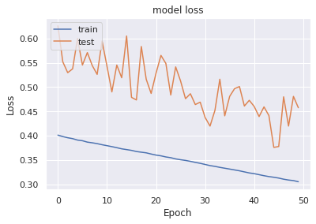

```python
#Plotting Train Loss vs Validation Loss
plt.plot(history.history['loss'])
plt.plot(history.history['val_loss'])
plt.title('model loss')
plt.ylabel('Loss')
plt.xlabel('Epoch')
plt.legend(['train', 'test'], loc='upper left')
plt.show()
```

- The model seems to be well fitted but unstable

```
Best Threshold=0.320241, G-Mean=0.754
```

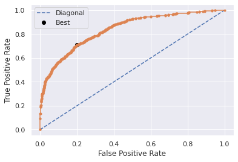

```python
from sklearn.metrics import roc_curve

from matplotlib import pyplot


# predict probabilities
yhat1 = estimator_v6.predict(X_test)
# keep probabilities for the positive outcome only
yhat1 = yhat1[:, 0]
# calculate roc curves
fpr, tpr, thresholds1 = roc_curve(y_test, yhat1)
# calculate the g-mean for each threshold
gmeans1 = np.sqrt(tpr * (1-fpr))
# locate the index of the largest g-mean
ix = np.argmax(gmeans1)
print('Best Threshold=%f, G-Mean=%.3f' % (thresholds1[ix], gmeans1[ix]))
# plot the roc curve for the model
pyplot.plot([0,1], [0,1], linestyle='--', label='Diagonal')
pyplot.plot(fpr, tpr, marker='.')
pyplot.scatter(fpr[ix], tpr[ix], marker='o', color='black', label='Best')
# axis labels
pyplot.xlabel('False Positive Rate')
pyplot.ylabel('True Positive Rate')
pyplot.legend()
# show the plot
pyplot.show()
```

```python
# Calculating different metrics on train set
ANN_train_7 = model_performance_classification_sklearn(estimator_v6, X_train_over, y_train_over)
print("Training performance:")
ANN_train_7
```

```
Training performance:
```

|  | Accuracy | Recall | Precision | F1 |
| --- | --- | --- | --- | --- |
| 0 | 0.836 | 0.950 | 0.774 | 0.853 |

```python
# Calculating different metrics on test set
ANN_test_7 = model_performance_classification_sklearn(estimator_v6, X_test, y_test)
print("Testing performance:")
ANN_test_7
```

```
Testing performance:
```

|  | Accuracy | Recall | Precision | F1 |
| --- | --- | --- | --- | --- |
| 0 | 0.705 | 0.794 | 0.389 | 0.522 |

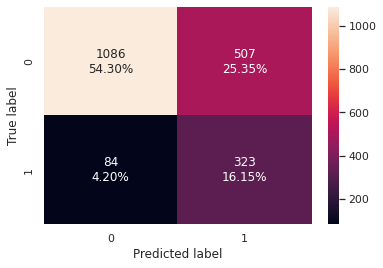

```python
# creating confusion matrix
confusion_matrix_sklearn(estimator_v6, X_test, y_test)
```